# Final Project: State and National Population and Voting Trends

Andrew Carson

December 18, 2016

#### Introduction

Do state populations bear any relationship to state voter turnouts and party selections in presidential elections? What can we learn about voter turnout and state party preference based on state populations? I intend to answer these questions in my exploration of state population data from 1900 through 2016 in comparison to state voting percentages and party selection from 1900 through 2016. I will use census data and federal elections data to do the analysis. This data is available on the web. I will download, clean, transform, analyze, and visualize the data using R and R Markdown.

#### Gather Data

Gathering the data was quite difficult and required a great deal of code due to the many source files from the Census Bureau and the many slightly varying webpages containing Presidential election data at the national and state levels. Consequently, I have placed that code in a separate file, located here: [GitHub](https://github.com/anrcarson/CUNY-MSDA/blob/master/DATA607/FinalProject/final_project_getdata.Rmd) [RPubs](http://rpubs.com/anrcarson/232668).

#### Clean/Transform Data

The code referenced in the above section output many different .csv files to my local computer, which I have placed in [GitHub](https://github.com/anrcarson/CUNY-MSDA/tree/master/DATA607/FinalProject). After joining similar files together, I have these 5 master files to use in the following analyses:

1. `state_population_1900_2015.csv`: Every state’s population from 1900 through 2015
2. `national_population_1900_2016.csv`: The United State’s national population from 1900 through 2016.
3. `state_header_df.csv`: The year and Presidential candidate names for each presidential election 1824 - 2016. This matches with the file `summary_state_df.csv`.
4. `summary_state_df.csv`: The year and total votes cast by state for each Presidential candidate from 1824 - 2016. This matches with the file `state_header_df.csv`.
5. `summary_df.csv`: The year, party, Presidential Candidate, Vice Presidential Candidate, Electoral Votes, Electoral Percentage, Popular Votes, and Popular Vote Percentage for each Presidential candidate from 1789 - 2016.

##### Verify Data

Before moving on, let’s verify the data that we have.

We have the state populations for each year 1900-2015. In 2015, CA has the largest state population at 39144818, followed by TX at 27469114 and FL at 20271272. The least populated states are WY (586107), VT (626042), and AK (738432).

```r
#state population
kable(head(state_population))
```

| State | Year | Population |
| --- | --- | --- |
| AL | 1900 | 1830000 |
| AR | 1900 | 1314000 |
| AZ | 1900 | 124000 |
| CA | 1900 | 1490000 |
| CO | 1900 | 543000 |
| CT | 1900 | 910000 |

```r
state_population %>% subset(Year==2015)%>%arrange(desc(Population))%>% head() %>%kable()
```

| State | Year | Population |
| --- | --- | --- |
| CA | 2015 | 39144818 |
| TX | 2015 | 27469114 |
| FL | 2015 | 20271272 |
| NY | 2015 | 19795791 |
| IL | 2015 | 12859995 |
| PA | 2015 | 12802503 |

```r
state_population %>% subset(Year==2015)%>%arrange(desc(Population))%>% tail() %>%kable()
```

|  | State | Year | Population |
| --- | --- | --- | --- |
| 46 | SD | 2015 | 858469 |
| 47 | ND | 2015 | 756927 |
| 48 | AK | 2015 | 738432 |
| 49 | DC | 2015 | 672228 |
| 50 | VT | 2015 | 626042 |
| 51 | WY | 2015 | 586107 |

We confirm that we have the national population from 1900-2016. The US population in 2016 was almost 324 million. Also shown below are the heads of the national election and state election files.

```r
#national population
kable(head(arrange(national_population, desc(Population))))
```

| Year | Population |
| --- | --- |
| 2016 | 323889854 |
| 2015 | 321418820 |
| 2014 | 318907401 |
| 2013 | 316427395 |
| 2012 | 314102623 |
| 2011 | 311718857 |

```r
#national election
kable(head(national_election))
```

| Year | Party | President | VicePresident | ElectoralVote | ElectoralPerc | PopularVote | PopularPerc |
| --- | --- | --- | --- | --- | --- | --- | --- |
| 1789 | unofficially Federalist | George Washington | NA | 69 | 100.0 | NA | NA |
| 1792 | unofficially Federalist | George Washington | NA | 132 | 100.0 | NA | NA |
| 1796 | Federalist | John Adams | NA | 71 | 51.1 | NA | NA |
| 1796 | Democratic-Republican | Thomas Jefferson | NA | 68 | 48.9 | NA | NA |
| 1800 | Democratic-Republican | Thomas Jefferson | NA | 73 | 52.9 | NA | NA |
| 1800 | Federalist | John Adams | NA | 65 | 47.1 | NA | NA |

```r
#state election
kable(head(state_election_data))
```

|  | State | Year | TotalPopularVote | Candidate1PopVotes | Candidate1PVPerc | Candidate1EV | Candidate2PopVotes | Candidate2PVPerc | Candidate2EV | Candidate3PopVotes | Candidate3PVPerc | Candidate3EV | Candidate4PopVotes | Candidate4PVPerc | Candidate4EV |
| --- | --- | --- | --- | --- | --- | --- | --- | --- | --- | --- | --- | --- | --- | --- | --- |
| 2 | AL | 1824 | 13603 | 2422 | 17.8 | NA | 9429 | 69.3 | 5 | 96 | 0.7 | NA | 1656 | 12.2 | NA |
| 3 | AL | 1828 | 18618 | 16736 | 89.9 | 5 | 1878 | 10.1 | NA | NA | NA | NA | NA | NA | NA |
| 4 | AL | 1832 | 14291 | 14286 | 100.0 | 7 | 5 | 0.0 | NA | NA | NA | NA | NA | NA | NA |
| 5 | AL | 1836 | 37296 | 20638 | 55.3 | 7 | NA | NA | NA | 16658 | 44.7 | NA | NA | NA | NA |
| 6 | AL | 1840 | 62511 | 28515 | 45.6 | NA | 33996 | 54.4 | 7 | NA | NA | NA | NA | NA | NA |
| 7 | AL | 1844 | 63403 | 37401 | 59.0 | 9 | 26002 | 41.0 | NA | NA | NA | NA | NA | NA | NA |

```r
kable(head(state_election_header))
```

| Year | Candidate1 | Candidate2 | Candidate3 | Candidate4 |
| --- | --- | --- | --- | --- |
| 1824 | ADAMS | JACKSON | CLAY | CRAWFORD |
| 1828 | ANDREW JACKSON | JOHN Q. ADAMS | NA | NA |
| 1832 | ANDREW JACKSON | HENRY CLAY | WILLIAM WIRT | NA |
| 1836 | MARTIN VAN BUREN | WILLIAM HENRY HARRISON | HUGH LAWSON WHITE | DANIEL WEBSTER |
| 1840 | WILLIAM H. HARRISON | MARTIN VAN BUREN | NA | NA |
| 1844 | JAMES K. POLK | HENRY CLAY | NA | NA |

#### Exploratory Data Analysis

##### Population

As visible below, the United States population has steadily increased since 1900. We can see slight changes during WWI and WWII in which the population growth slowed and then was followed by a boom. Since then, the growth rate has been pretty consistent. (Note: there is a slight jump between 1999 and 2000 due to a change in the data source.)

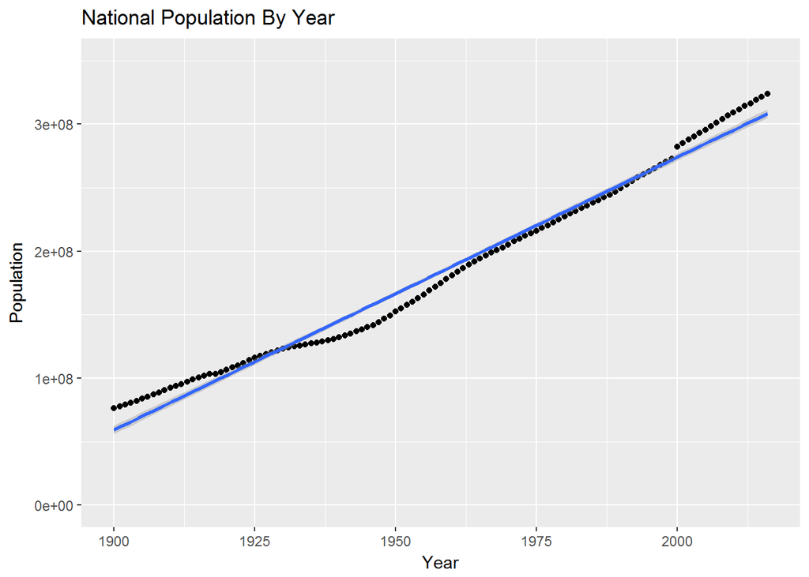

At the state level, we can see that several states have very large and growing populations (CA, FL, TX) while others appear to have plateaued (NY, DC, WV). This is easier to see in the second plot, which frees the y axis to the appropriate scale for each state. We can also see periods of rapid change. ND in particular is interesting in that it experience rapid growth, rapid decline, slow growth, and then recently, extremely rapid growth (due to oil fracking industry).

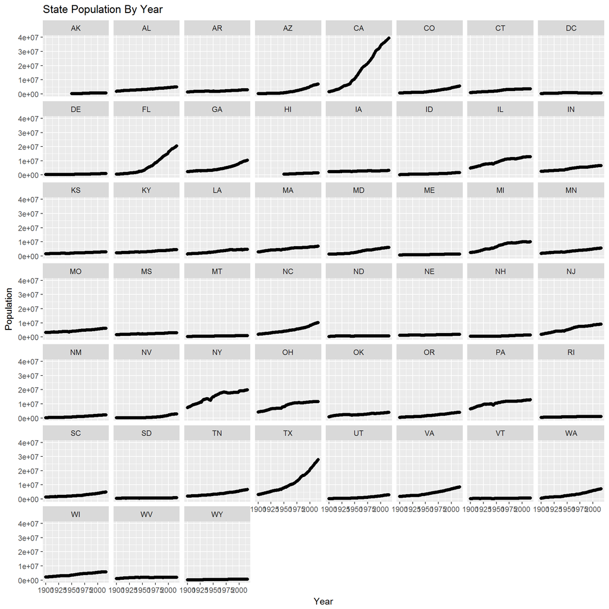

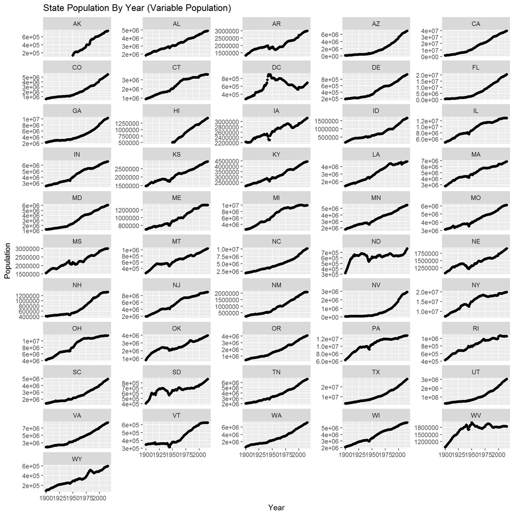

What about state population as a ratio to the national population? We can see that several states have increased over time (CA, TX, FL) while others have decreased (NY, PA, IL). This again is easier to see when the y axis is free, which reveals many very interesting population changes in states.

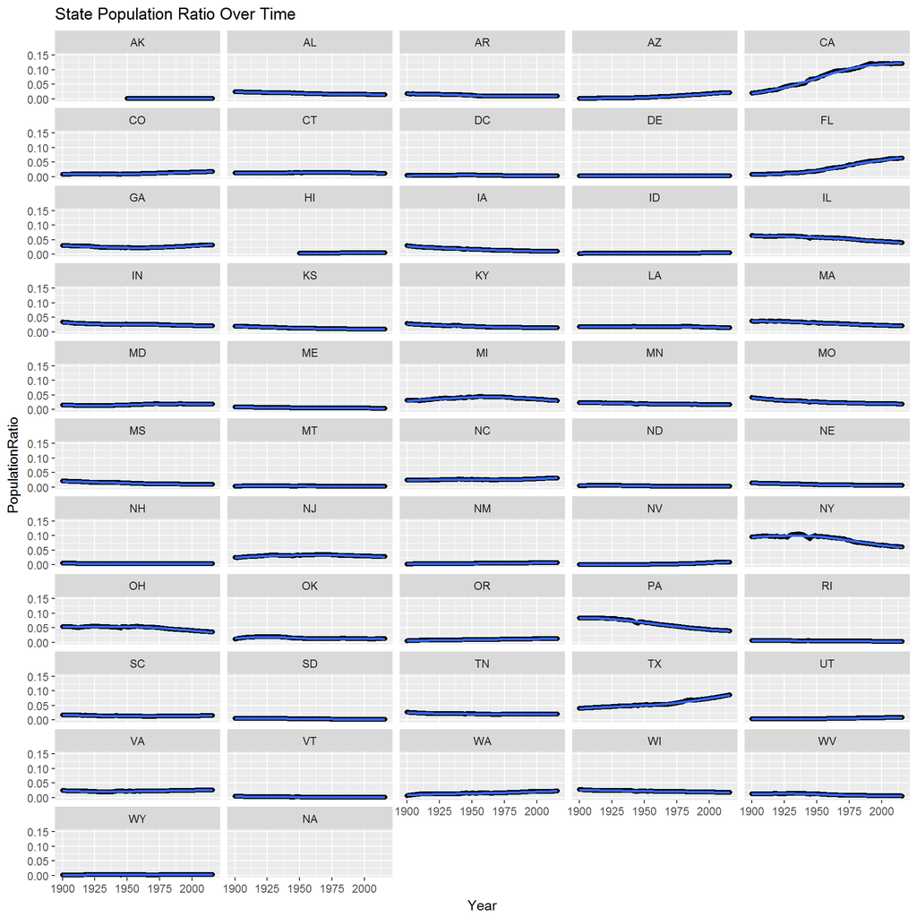

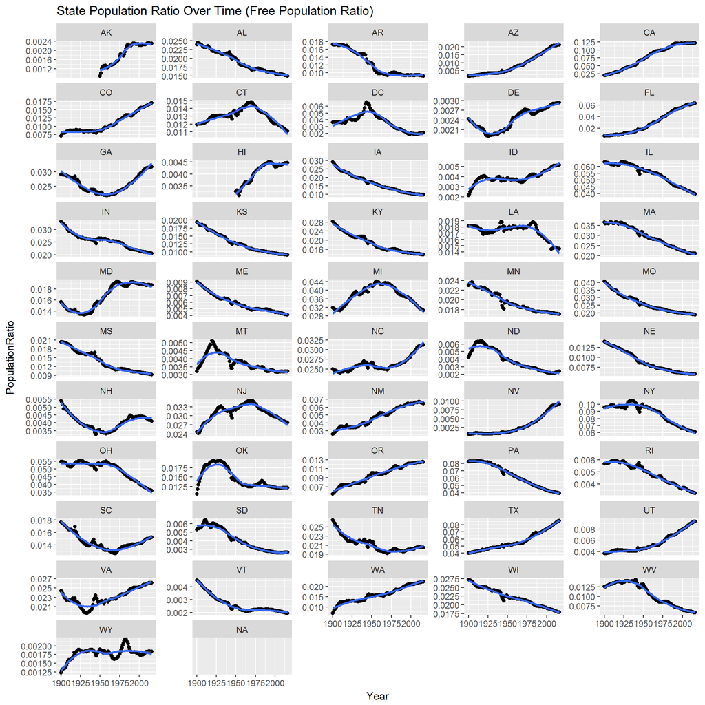

We can visualize the above information differently using a map of the United States. This first map shows that change in absolute population for each state from 1900-2016. The map starts dark in 1900, but various states begin to emerge as their populations increase. Early on we can see NY, PA, IL, and TX emerging. CA begins to be noticeable in the 1920s. FL becomes more noticeable in the 1980s. Today, we can see that CA, TX, FL, NY, and IL have large populations.

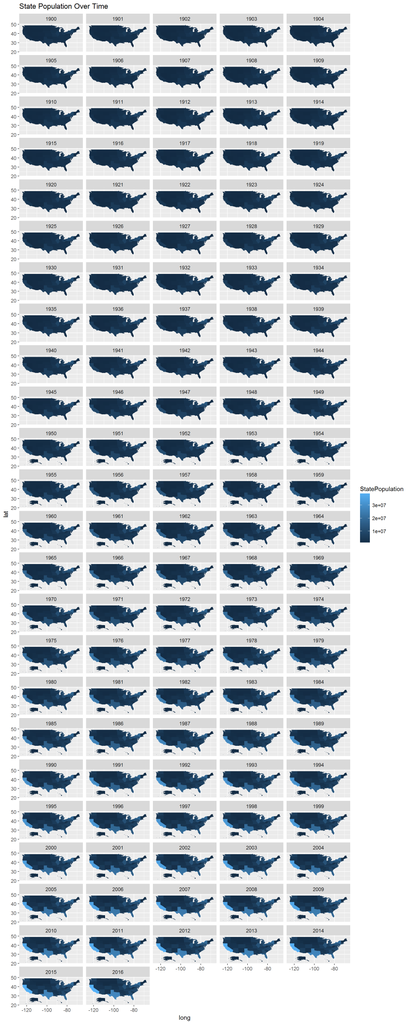

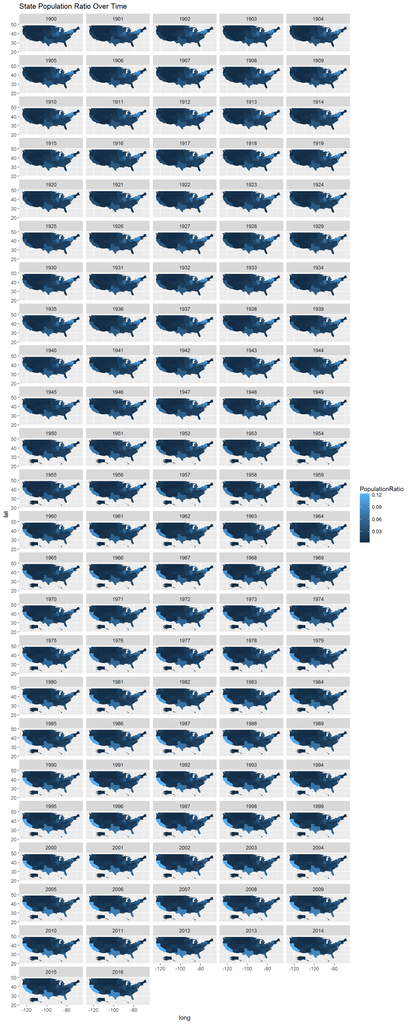

###### Voting

Notice the only dot below 50% occurred in 1824 in a contest between between Andrew Jackson and John Quincy Adams. While Jackson got more electoral votes, the election went to the House of Representatives for a vote because no candidate got a majority. Adams was then elected President by the House.

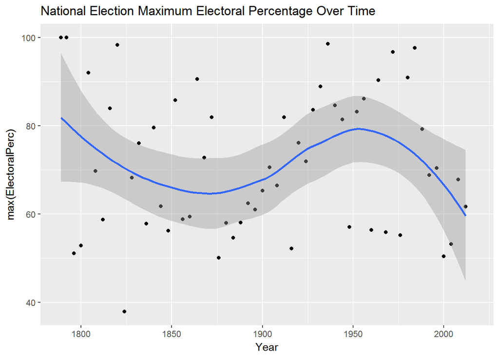

The popular vote percentage tells a similar story, but perhaps less extreme because it is the popular vote percentages as opposed to electoral vote percentages. We can see that the highest popular vote percentage was 61% in 1964 by Lyndon B. Johnson. The least was in 1860, when Abraham Lincoln received only 39.9% of the popular vote.

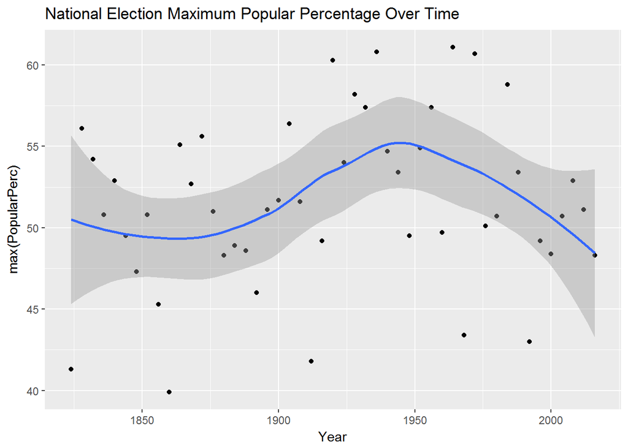

| Year | max(PopularPerc) |
| --- | --- |
| 1964 | 61.1 |
| 1936 | 60.8 |
| 1972 | 60.7 |
| 1920 | 60.3 |
| 1984 | 58.8 |
| 1928 | 58.2 |

| Year | max(PopularPerc) |
| --- | --- |
| 1860 | 39.9 |
| 1824 | 41.3 |
| 1912 | 41.8 |
| 1992 | 43.0 |
| 1968 | 43.4 |
| 1856 | 45.3 |

How does the national population relate to the national popular vote? As you can see by the graphs below, the relationship is very linear. This is not especially uprising, for as the population increases, so does the voting population. What is more revealing is that a look at the ratio of popular vote to population over time shows that this ratio is increasing. The trend is not perfect (people voted less prior to and during WWI), but overall we see an increase in voting rate that is slowing over time. In other words, more people are voting in each election, but that increase is getting relatively smaller and smaller. Perhaps the ratio will get closer to 45%, but never pass over.

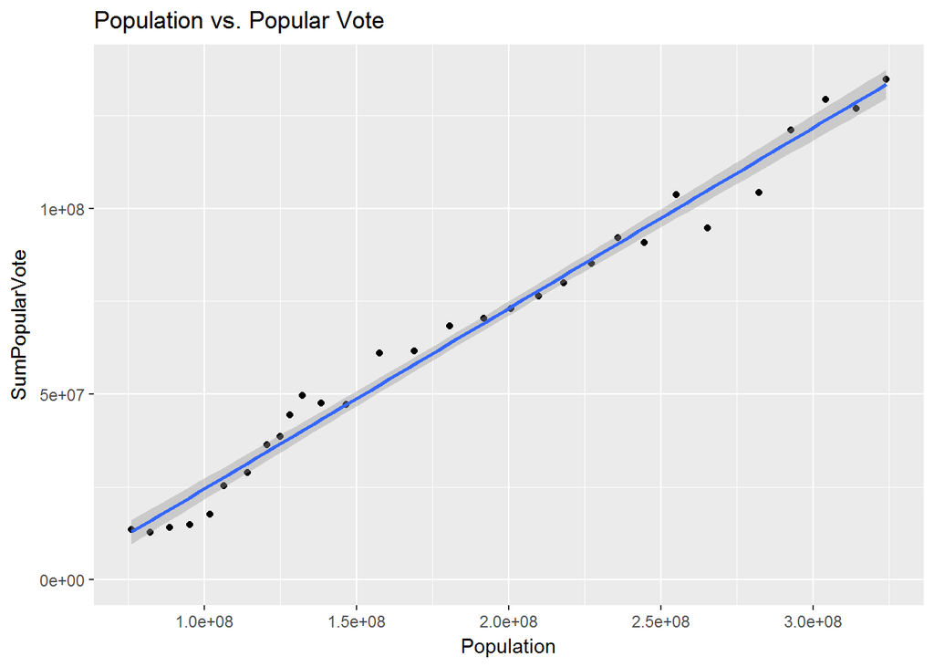

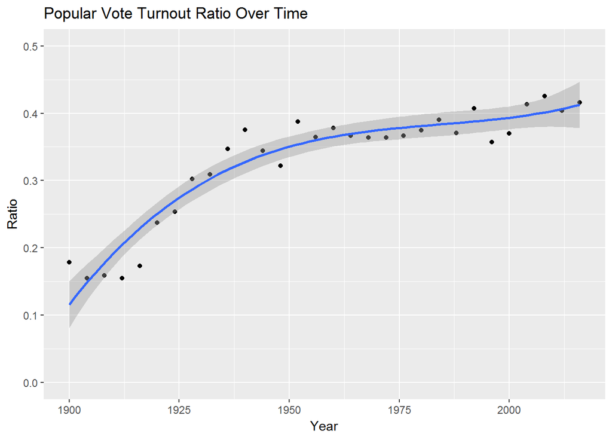

Why might the voting ratio be increasing over time? We know that the population is increasing over time, as is the population density. Below I calculate the population density. You can see from a simple linear model that `Year` is a better predictor of the ratio, but `PopulationDensity` is pretty good too. We will come back to that later.

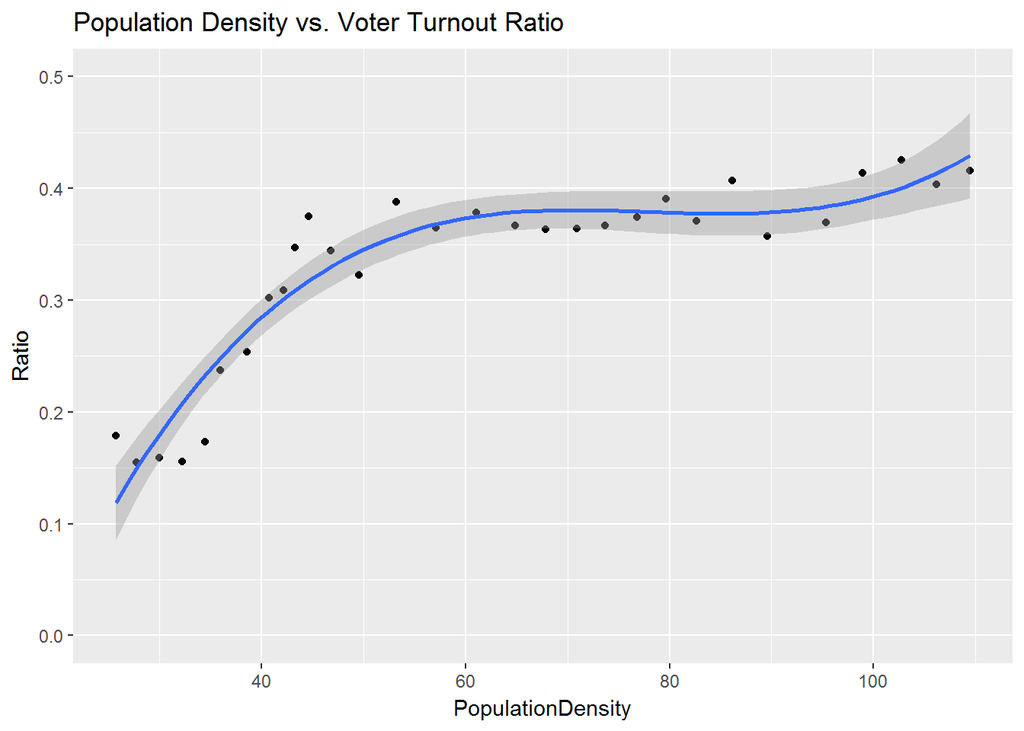

```
##
## Call:
## lm(formula = Ratio ~ Year, data = national)
##
## Residuals:
##       Min        1Q    Median        3Q       Max
## -0.075665 -0.032212  0.000921  0.033547  0.085421
##
## Coefficients:
##               Estimate Std. Error t value Pr(>|t|)
## (Intercept) -3.7913331  0.4502621  -8.420 3.70e-09 ***
## Year         0.0021037  0.0002299   9.149 6.59e-10 ***
## ---
## Signif. codes:  0 '***' 0.001 '**' 0.01 '*' 0.05 '.' 0.1 ' ' 1
##
## Residual standard error: 0.0436 on 28 degrees of freedom
##   (115 observations deleted due to missingness)
## Multiple R-squared:  0.7494, Adjusted R-squared:  0.7404
## F-statistic: 83.71 on 1 and 28 DF,  p-value: 6.594e-10
```

```
##
## Call:
## lm(formula = Ratio ~ PopulationDensity, data = national)
##
## Residuals:
##       Min        1Q    Median        3Q       Max
## -0.091947 -0.040616  0.008271  0.032232  0.094746
##
## Coefficients:
##                    Estimate Std. Error t value Pr(>|t|)
## (Intercept)       0.1609169  0.0249159   6.458 5.38e-07 ***
## PopulationDensity 0.0026782  0.0003706   7.227 7.25e-08 ***
## ---
## Signif. codes:  0 '***' 0.001 '**' 0.01 '*' 0.05 '.' 0.1 ' ' 1
##
## Residual standard error: 0.05145 on 28 degrees of freedom
##   (115 observations deleted due to missingness)
## Multiple R-squared:  0.651,  Adjusted R-squared:  0.6385
## F-statistic: 52.23 on 1 and 28 DF,  p-value: 7.246e-08
```

At the state level, we can also view trends in voting percentages. The below plot shows that most states do have an increasing popular vote to state population ratio over time, but that it has slowed in recent years or plateaued. Others do not, however. CA appears to have peaked at 47% in 1940 and has declined since. HI has been relatively flat at 32% since it become a state. Overall, it looks like southern states have continued to increase in their voting ratios while northern and western states have not or have slowed dramatically. I would suspect that the civil war and civil rights movements can explain much of the initial low turnout and the subsequent increase in the south.

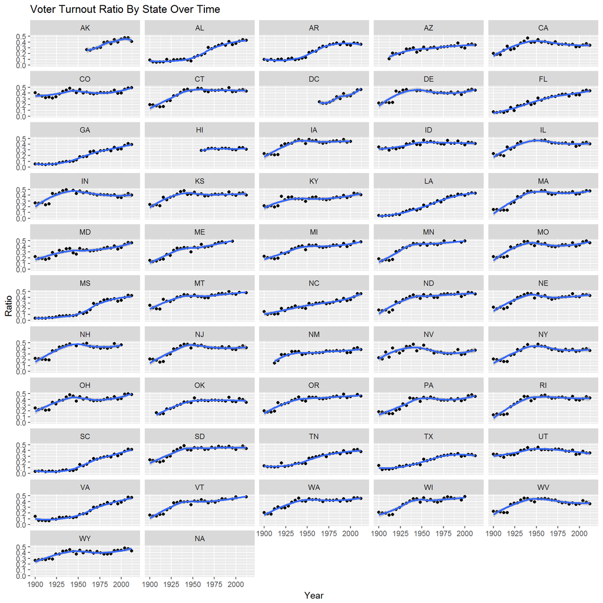

| State | Year | SumPopularVote | StatePopulation | Ratio | NationalPopulation | PopulationRatio |
| --- | --- | --- | --- | --- | --- | --- |
| ME | 2004 | 740752 | 1313688 | 0.5638721 | 292805298 | 0.0044866 |
| ME | 2016 | 747927 | 1330272 | 0.5622361 | 323889854 | 0.0041072 |
| NH | 2016 | 744296 | 1332924 | 0.5583935 | 323889854 | 0.0041154 |
| MN | 2004 | 2828387 | 5087713 | 0.5559250 | 292805298 | 0.0173758 |
| MN | 2008 | 2910369 | 5247018 | 0.5546711 | 304093966 | 0.0172546 |
| ME | 1992 | 679499 | 1235748 | 0.5498686 | 255029699 | 0.0048455 |

| State | Year | SumPopularVote | StatePopulation | Ratio | NationalPopulation | PopulationRatio |
| --- | --- | --- | --- | --- | --- | --- |
| CA | 2016 | 0 | 39509088.1 | 0.0000000 | 323889854 | 0.1219831 |
| IN | 2016 | 0 | 6647711.7 | 0.0000000 | 323889854 | 0.0205246 |
| MN | 2016 | 0 | 5527177.9 | 0.0000000 | 323889854 | 0.0170650 |
| MT | 2016 | 0 | 1040420.8 | 0.0000000 | 323889854 | 0.0032123 |
| SD | 2016 | 0 | 869563.7 | 0.0000000 | 323889854 | 0.0026848 |
| SC | 1924 | 50755 | 1710000.0 | 0.0296813 | 114109000 | 0.0149857 |

| State | Year | SumPopularVote | StatePopulation | Ratio | NationalPopulation | PopulationRatio |
| --- | --- | --- | --- | --- | --- | --- |
| TX | 2012 | 7993851 | 26089741 | 0.3063983 | 314102623 | 0.0830612 |
| HI | 2012 | 434697 | 1392641 | 0.3121386 | 314102623 | 0.0044337 |
| CA | 2012 | 13038547 | 38056055 | 0.3426143 | 314102623 | 0.1211580 |
| OK | 2012 | 1334872 | 3817679 | 0.3496554 | 314102623 | 0.0121542 |
| AZ | 2012 | 2299254 | 6553262 | 0.3508564 | 314102623 | 0.0208634 |
| UT | 2012 | 1017440 | 2856343 | 0.3562037 | 314102623 | 0.0090937 |

We can also visualize this information using a map of the United States. As mentioned above, it looks like most states but particularly the south had little voter turnout before 1920. After 1920, the south continued to have low voter turnout until the 1960s. Since then, the south has come to have voter turnout similar to all other states. (Note: data for the 2016 election was not fully published by several states as of the final data pull on 12/15/16. Consequently, these states have a “0%” voter turnout ratio.)

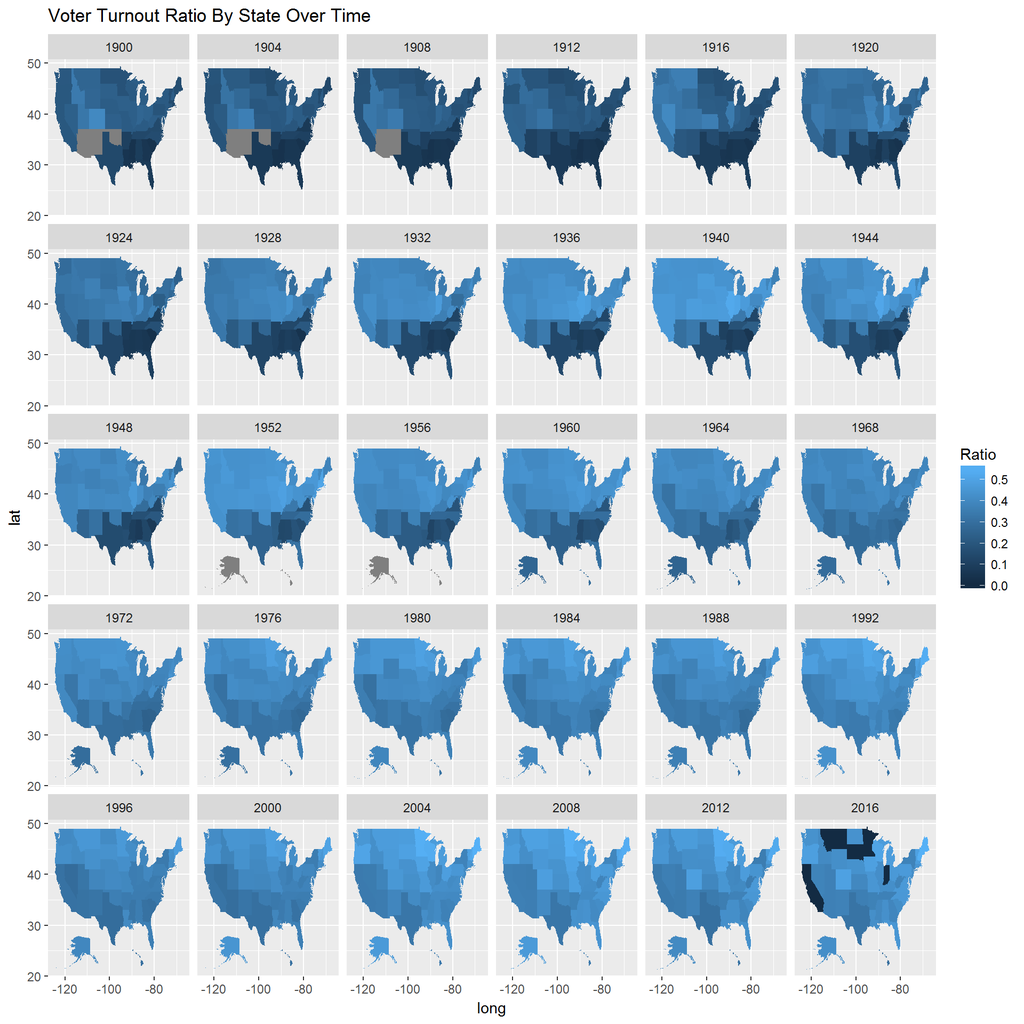

What about candidates and parties? We use the below code to find the winning candidate and party for each state for each voting year from 1824 - 2016.

We can visualize the information using the mapping capabilities from `ggplot2`. We produce a map of the United States for each voting year 1824 - 2016 and color each state with the winning party. The Democratic party is in blue while the Republican party is in red. Other parties are in various colors.

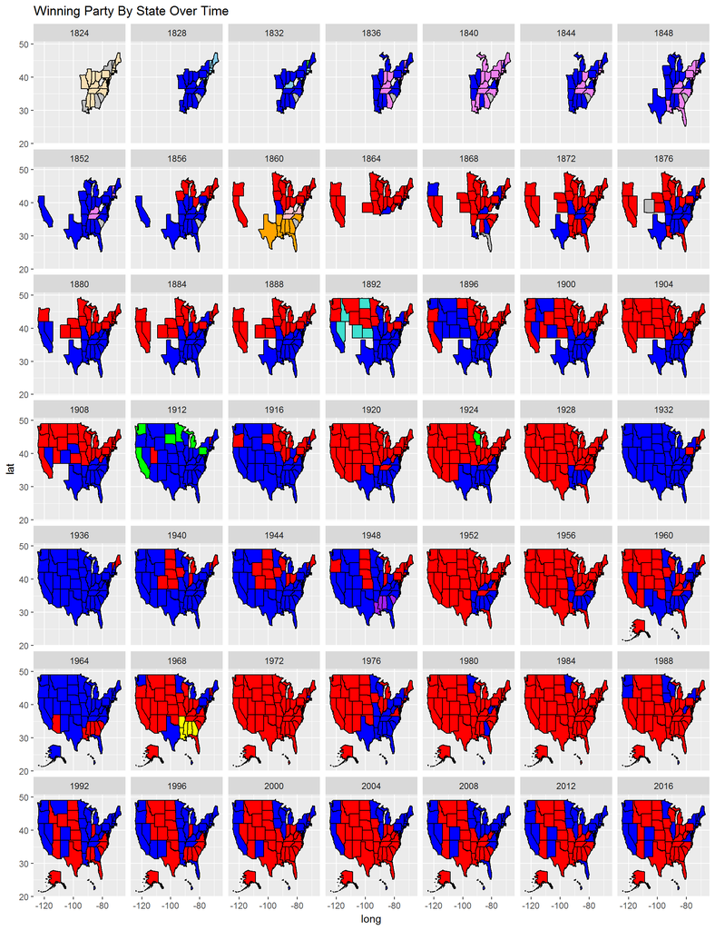

My strategy then was to find the year at which a state switched from having a past of being “Democrat” to having a future of being “Republican”, and vice versa. I started with the year 1920, which is a year when the south is clearly Democratic in the old sense (conservative, state oriented) and the rest of the country is Republican in the old sense (liberal, national oriented), which contrasts with our present state/party orientation (south=“Republican”, most of the rest of the country = “Democrat”). I then assigned a 1 to each state for each year if the state was labeled as “Democratic” and a 0 if the state was labeled “Republican”.

I then found the year in which the running average over 10 elections for a Democratic (old sense) starting state switched from being above .5 to being below .5, indicating a switch to being “Republican” (current sense). Similarly, I found the year when a starting Republican (old sense) state switched from being below .5 to being above .5 in the running average over 10 elections, meaning it had switched to being “Democratic” (current sense). I averaged the years in which this switch occurred for all of the states in which a switch did occur. This was the estimated year in which the meaning of “Democrat” and “Republican” switched to be more similar to the other term’s previous meaning going forward.

Which year did I calculate? The average was 1966.211, and the median was 1964. This is consistent with my above visual conclusion, and it makes sense when we look at the map. Before 1964, the southern states are regularly, although not always, Democrat as a group, even when the rest of the country is Republican (in 1948, they were the “State’s Rights” party). In 1964, the rest of the country is “Democratic”, but the southern states as a group are “Republican” for the first time. In 1968, the south votes for the “American Independent” party, but afterwards, apart from 1976, the south as a group regularly goes “Republican”.

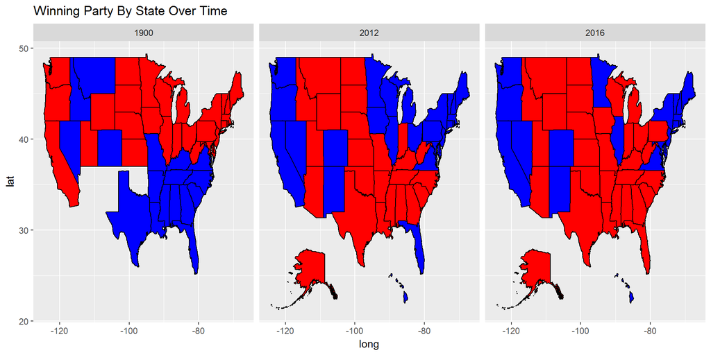

#### Predicting Voter Turnout and Party

##### Voter Turnout

Can we predict voter turnout? Let’s start with a state’s population ratio. From the graph below, we can see that there isn’t really any relationship.

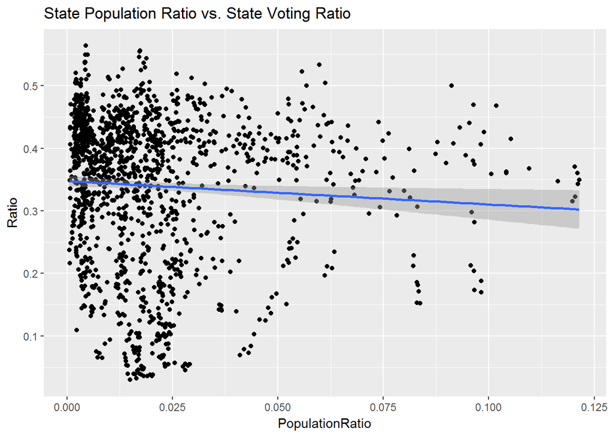

What about population density? In order to calculate population density, we need to read in the square miles in each state. This is done below.

|  | State | Land sq miles |
| --- | --- | --- |
| 4 | Alaska | 570374 |
| 5 | Texas | 261914 |
| 6 | California | 155973 |
| 7 | Montana | 145556 |
| 8 | New Mexico | 121365 |
| 9 | Arizona | 113642 |

Now that we have the square miles of land per state, we can calculate the population density per state per year.

Does the state population density correlate with the voter turnout ratio? As the plot below shows, there doesn’t seem to much much of a relationship. We get an R^2 value of 0.04, which doesn’t mean much.

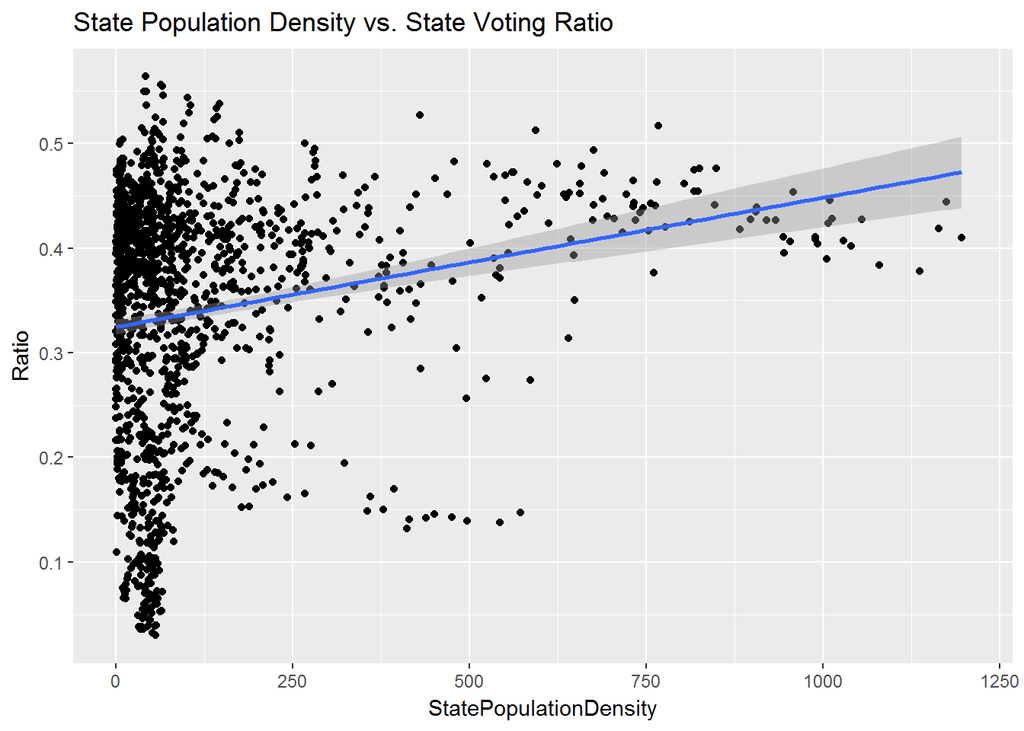

```
##
## Call:
## lm(formula = Ratio ~ StatePopulationDensity, data = state)
##
## Residuals:
##      Min       1Q   Median       3Q      Max
## -0.35744 -0.06098  0.02820  0.08471  0.23253
##
## Coefficients:
##                         Estimate Std. Error t value Pr(>|t|)
## (Intercept)            3.261e-01  3.670e-03  88.840  < 2e-16 ***
## StatePopulationDensity 1.238e-04  1.557e-05   7.951 3.67e-15 ***
## ---
## Signif. codes:  0 '***' 0.001 '**' 0.01 '*' 0.05 '.' 0.1 ' ' 1
##
## Residual standard error: 0.1174 on 1460 degrees of freedom
##   (5018 observations deleted due to missingness)
## Multiple R-squared:  0.0415, Adjusted R-squared:  0.04085
## F-statistic: 63.22 on 1 and 1460 DF,  p-value: 3.674e-15
```

What if we look at each state individually? From the plot below, we can see that, for each state, as population density increases relative to the state, so does voter turnout. But this is problematic since then we can’t use population density as a common variable to predict voter turnout.

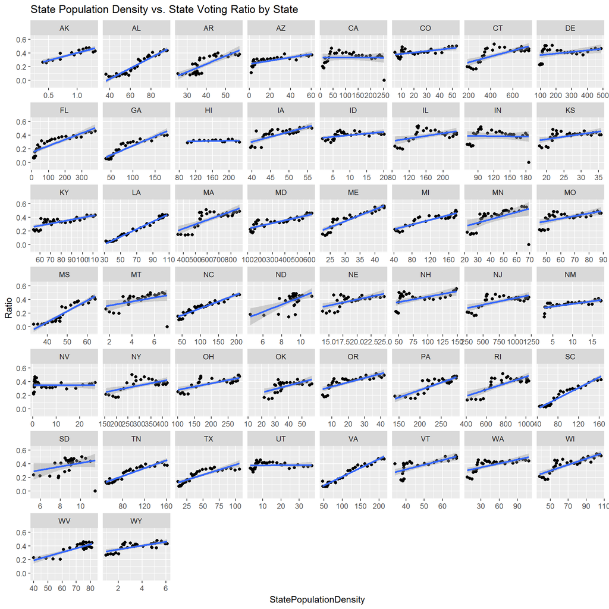

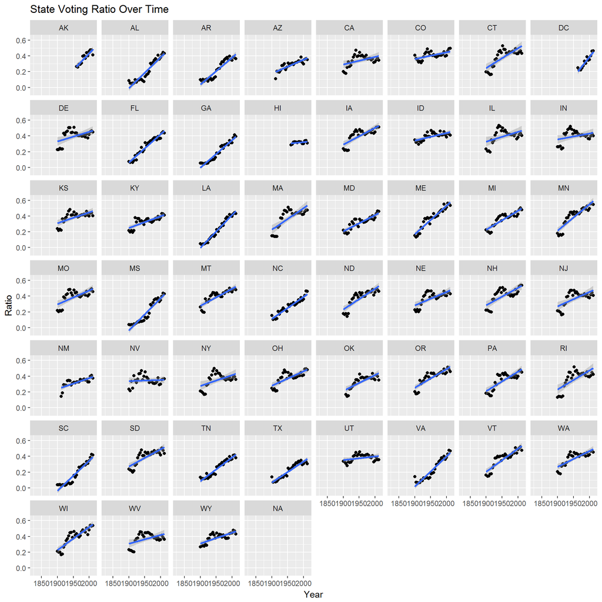

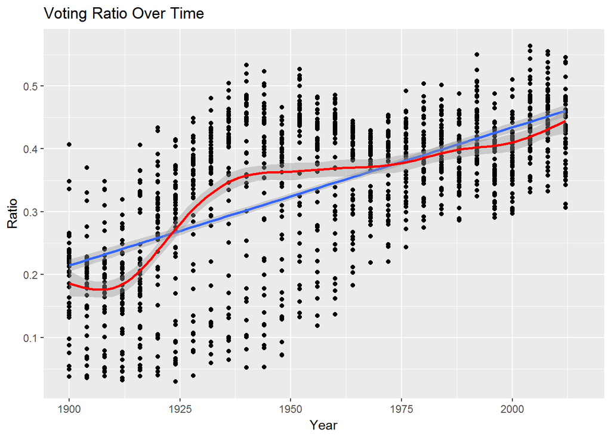

```
##
## Call:
## lm(formula = Ratio ~ Year, data = state)
##
## Residuals:
##      Min       1Q   Median       3Q      Max
## -0.45967 -0.05768  0.00548  0.06830  0.23138
##
## Coefficients:
##               Estimate Std. Error t value Pr(>|t|)
## (Intercept) -3.718e+00  1.420e-01  -26.18   <2e-16 ***
## Year         2.072e-03  7.246e-05   28.59   <2e-16 ***
## ---
## Signif. codes:  0 '***' 0.001 '**' 0.01 '*' 0.05 '.' 0.1 ' ' 1
##
## Residual standard error: 0.09597 on 1474 degrees of freedom
##   (5004 observations deleted due to missingness)
## Multiple R-squared:  0.3568, Adjusted R-squared:  0.3564
## F-statistic: 817.7 on 1 and 1474 DF,  p-value: < 2.2e-16
```

##### Party Prediction

Can we predict the winning party in any state using the population variables we have looked at? I subset the data to only look at elections from 1970 onward so as to ensure that “Democratic” and “Republican” have roughly the same meaning as today.

In the first box plot comparing Party to the state population, we can see that there isn’t much separation in the parties. The same is true in the second box plot that uses population ratio. However, the third box plot which uses population density does provide some noticeable separation.

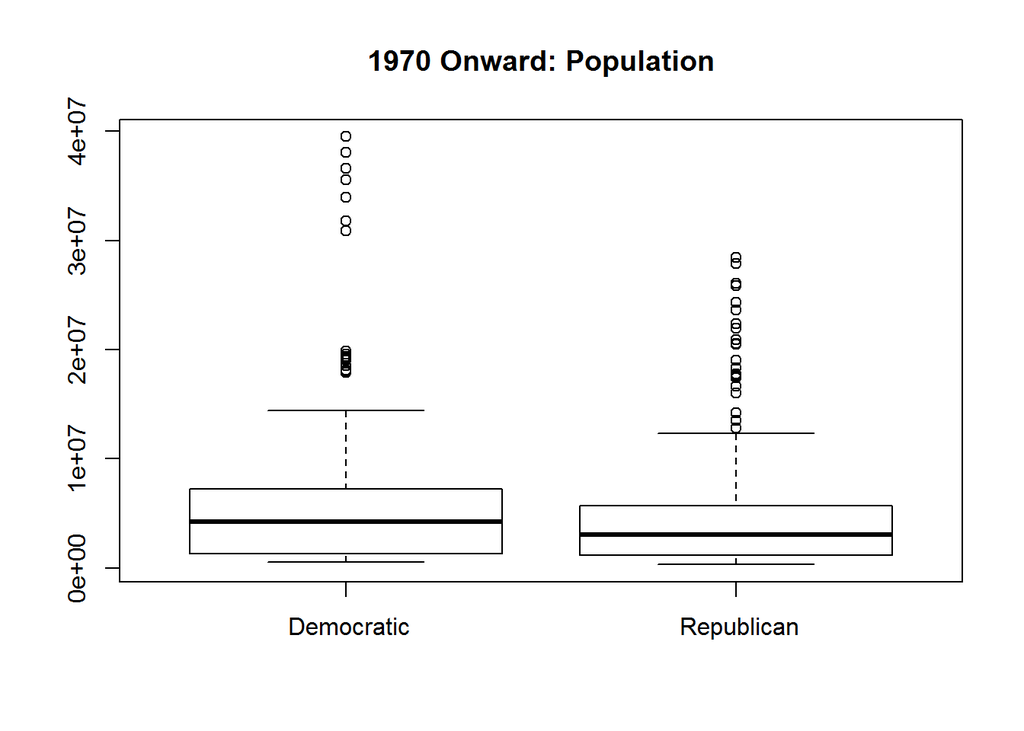

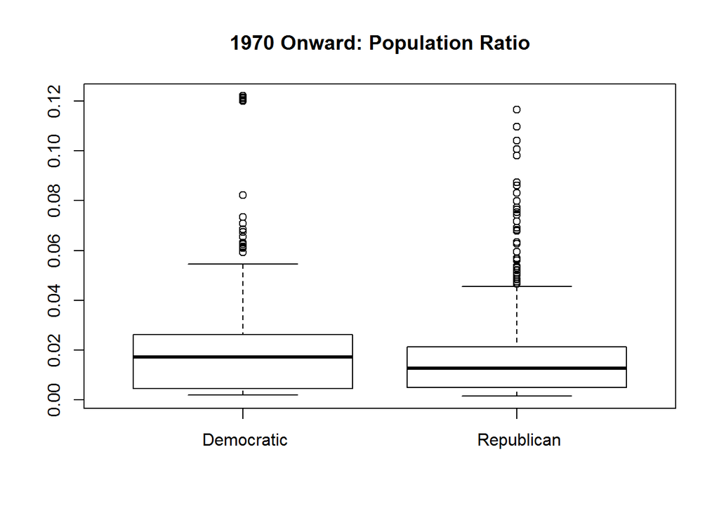

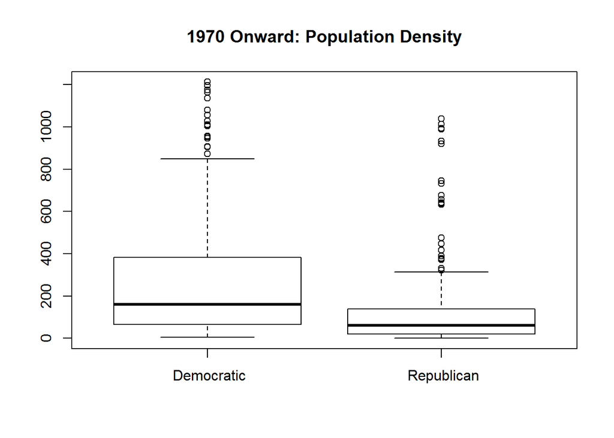

If we subset the data to only include elections from 1990 onward, we can see a similar but more pronounced pattern to what we saw above. Both population and population ratio do not matter much, but population density matters a great deal.

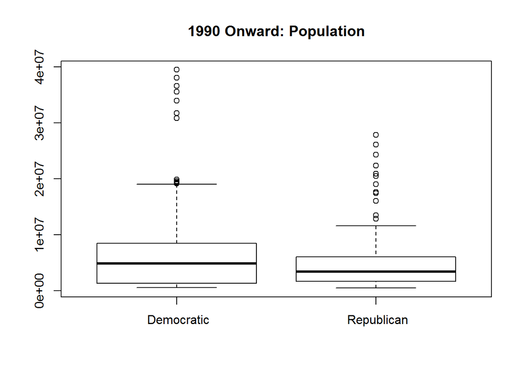

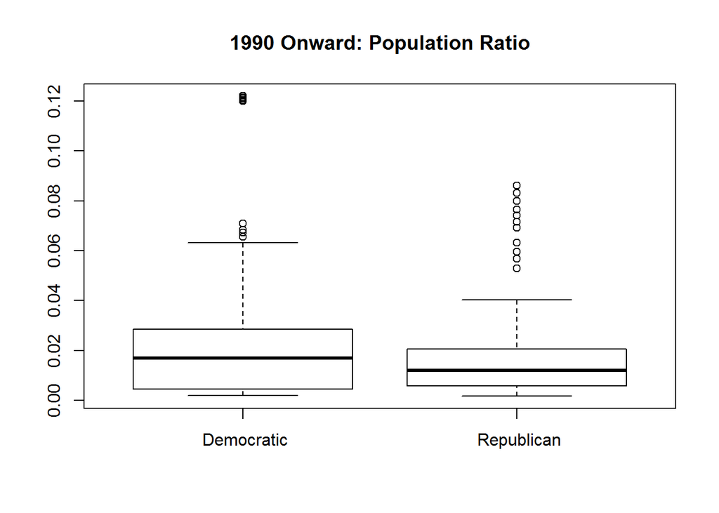

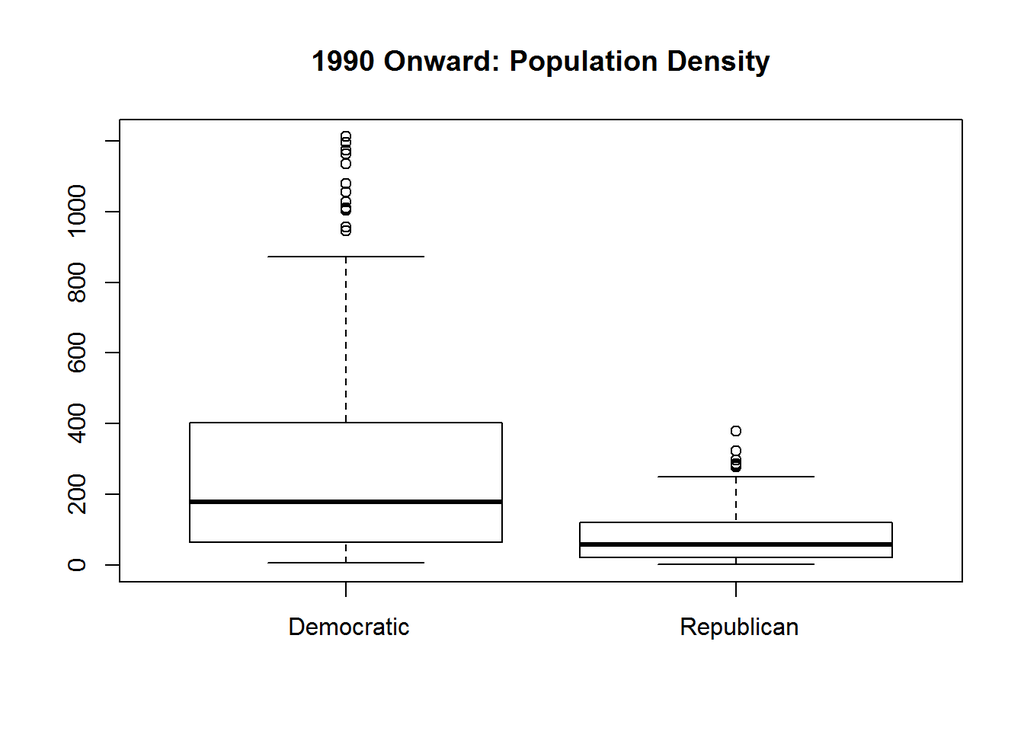

```
##
## Call:
## lm(formula = Republican ~ StatePopulationDensity, data = state_population_party_sub)
##
## Residuals:
##     Min      1Q  Median      3Q     Max
## -0.7513 -0.5690  0.2571  0.3042  0.9452
##
## Coefficients:
##                          Estimate Std. Error t value Pr(>|t|)
## (Intercept)             7.551e-01  2.282e-02  33.086   <2e-16 ***
## StatePopulationDensity -6.736e-04  7.709e-05  -8.738   <2e-16 ***
## ---
## Signif. codes:  0 '***' 0.001 '**' 0.01 '*' 0.05 '.' 0.1 ' ' 1
##
## Residual standard error: 0.4532 on 598 degrees of freedom
## Multiple R-squared:  0.1132, Adjusted R-squared:  0.1117
## F-statistic: 76.36 on 1 and 598 DF,  p-value: < 2.2e-16
```

```
##
## Call:
## lm(formula = Republican ~ StatePopulationDensity, data = subset(state_population_party_sub,
##     Year >= 1990))
##
## Residuals:
##     Min      1Q  Median      3Q     Max
## -0.6485 -0.5041  0.3476  0.3950  0.6656
##
## Coefficients:
##                          Estimate Std. Error t value Pr(>|t|)
## (Intercept)             6.533e-01  3.030e-02  21.563   <2e-16 ***
## StatePopulationDensity -8.403e-04  9.724e-05  -8.642   <2e-16 ***
## ---
## Signif. codes:  0 '***' 0.001 '**' 0.01 '*' 0.05 '.' 0.1 ' ' 1
##
## Residual standard error: 0.455 on 348 degrees of freedom
## Multiple R-squared:  0.1767, Adjusted R-squared:  0.1743
## F-statistic: 74.68 on 1 and 348 DF,  p-value: < 2.2e-16
```

```
##
## Call:
## lm(formula = Republican ~ StatePopulationDensity, data = subset(state_population_party_sub,
##     Year >= 2000))
##
## Residuals:
##     Min      1Q  Median      3Q     Max
## -0.7073 -0.5165  0.2877  0.3485  0.6210
##
## Coefficients:
##                          Estimate Std. Error t value Pr(>|t|)
## (Intercept)             0.7208320  0.0350185  20.584  < 2e-16 ***
## StatePopulationDensity -0.0009008  0.0001095  -8.225 1.11e-14 ***
## ---
## Signif. codes:  0 '***' 0.001 '**' 0.01 '*' 0.05 '.' 0.1 ' ' 1
##
## Residual standard error: 0.4429 on 248 degrees of freedom
## Multiple R-squared:  0.2143, Adjusted R-squared:  0.2111
## F-statistic: 67.65 on 1 and 248 DF,  p-value: 1.106e-14
```

#### Conclusion

So what can we conclude? It seems we can draw these various conclusions about population and voting trends in the United States. The United States population as a whole is steadily increasing. At the state level, however, some states are growing both absolutely or proportionally while others are not.

With respect to voting, while our current political situation is rather divisive, this is not uncommon in the past. Divisive elections have swiftly been followed by relatively unified elections, and vice versa. The political map of the United States has changed often, and will almost certainly change again. So the current divisive situation should not lead us to despair.

What is encouraging is that the level of political participation through voting is higher than its ever been at the national level. However, this increase does seem to be slowing down. In individual states, it appears to have plateaued or decreased. Such places present opportunities to make a renewed effort to “get out the vote”.

Finally, population density seems to be a significant factor, especially more recently, in predicting party outcome. It should not surprise us that in less populated states, where people live more independently, traditionally, and may not be in need of government assistance and coordinated social planning, a Republican platform (less government, traditional values, less taxation) would be more appealing. As urbanization occurs requiring more social cooperation and interaction in meeting social needs and demands in an increasingly diverse population, it makes sense that a Democratic platform (social welfare, government programs and projects, heterogeneous values) would become more appealing.

This is certainly not the whole story (this would at most explain 20% of the variance in party preference), but it is reasonable interpretation of why population density aligns to significant degree with party preference.